# Week-4-Day-1-Advanced Logistic Regression & Classification Theory-Live-Session

### **PART 1: The Statistical Baseline (statsmodels)**

#### **1.1 Formulating Logistic Regression with Interaction Terms**

#### **NOTE: Dummy Variable Trap**

In statsmodels, we MUST use drop_first=True (or Treatment coding) to avoid perfect multicollinearity (the dummy variable trap) when an intercept is present.

```python
formula = "HD ~ Age + Sex_Label + Age:Sex_Label + ExAng + Oldpeak + C(ChestPain, Treatment('typical'))"
```

#### **Fit the model using Maximum Likelihood Estimation**

```python
stat_model = smf.logit(formula, data=df).fit(disp=0)
print("\n[1.1] Statistical Model Summary (with Age * Sex interaction):")
print(stat_model.summary().tables[1])
```

```
[1.1] Statistical Model Summary (with Age * Sex interaction):
======================================================================================================================
                                                         coef    std err          z      P>|z|      [0.025      0.975]
----------------------------------------------------------------------------------------------------------------------
Intercept                                             -6.8953      2.289     -3.013      0.003     -11.381      -2.410
Sex_Label[T.Male]                                      1.8756      2.459      0.763      0.446      -2.943       6.694
C(ChestPain, Treatment('typical'))[T.asymptomatic]     2.2927      0.592      3.874      0.000       1.133       3.453
C(ChestPain, Treatment('typical'))[T.nonanginal]       0.2217      0.606      0.366      0.715      -0.967       1.410
C(ChestPain, Treatment('typical'))[T.nontypical]       0.7095      0.685      1.036      0.300      -0.633       2.052
Age                                                    0.0578      0.037      1.573      0.116      -0.014       0.130
Age:Sex_Label[T.Male]                                 -0.0037      0.042     -0.088      0.930      -0.087       0.079
ExAng                                                  1.0292      0.356      2.894      0.004       0.332       1.726
Oldpeak                                                0.7586      0.169      4.487      0.000       0.427       1.090
======================================================================================================================
```

```python
print(stat_model.summary())
```

```
                           Logit Regression Results
==============================================================================
Dep. Variable:                     HD   No. Observations:                  303
Model:                          Logit   Df Residuals:                      294
Method:                           MLE   Df Model:                            8
Date:                Wed, 26 Aug 2026   Pseudo R-squ.:                  0.3874
Time:                        15:17:20   Log-Likelihood:                -128.02
converged:                       True   LL-Null:                       -208.99
Covariance Type:            nonrobust   LLR p-value:                 6.289e-31
======================================================================================================================
                                                         coef    std err          z      P>|z|      [0.025      0.975]
----------------------------------------------------------------------------------------------------------------------
Intercept                                             -6.8953      2.289     -3.013      0.003     -11.381      -2.410
Sex_Label[T.Male]                                      1.8756      2.459      0.763      0.446      -2.943       6.694
C(ChestPain, Treatment('typical'))[T.asymptomatic]     2.2927      0.592      3.874      0.000       1.133       3.453
C(ChestPain, Treatment('typical'))[T.nonanginal]       0.2217      0.606      0.366      0.715      -0.967       1.410
C(ChestPain, Treatment('typical'))[T.nontypical]       0.7095      0.685      1.036      0.300      -0.633       2.052
Age                                                    0.0578      0.037      1.573      0.116      -0.014       0.130
Age:Sex_Label[T.Male]                                 -0.0037      0.042     -0.088      0.930      -0.087       0.079
ExAng                                                  1.0292      0.356      2.894      0.004       0.332       1.726
Oldpeak                                                0.7586      0.169      4.487      0.000       0.427       1.090
======================================================================================================================
```

#### **1.2 Extracting Odds Ratios and p-values**

```python
params = stat_model.params
pvalues = stat_model.pvalues
odds_ratios = np.exp(params)
conf_int = np.exp(stat_model.conf_int())

or_df = pd.DataFrame({
    'Odds Ratio': odds_ratios,
    'CI Lower': conf_int[0],
    'CI Upper': conf_int[1],
    'P-value': pvalues
})
print("\n[1.2] Clinical Interpretability: Adjusted Odds Ratios")
or_df.round(3)
```

```
[1.2] Clinical Interpretability: Adjusted Odds Ratios
```

|  | Odds Ratio | CI Lower | CI Upper | P-value |
| --- | --- | --- | --- | --- |
| Intercept | 0.001 | 0.000 | 0.090 | 0.003 |
| Sex_Label[T.Male] | 6.525 | 0.053 | 807.814 | 0.446 |
| C(ChestPain, Treatment('typical'))[T.asymptomatic] | 9.902 | 3.104 | 31.585 | 0.000 |
| C(ChestPain, Treatment('typical'))[T.nonanginal] | 1.248 | 0.380 | 4.097 | 0.715 |
| C(ChestPain, Treatment('typical'))[T.nontypical] | 2.033 | 0.531 | 7.786 | 0.300 |
| Age | 1.059 | 0.986 | 1.139 | 0.116 |
| Age:Sex_Label[T.Male] | 0.996 | 0.917 | 1.083 | 0.930 |
| ExAng | 2.799 | 1.394 | 5.619 | 0.004 |
| Oldpeak | 2.135 | 1.533 | 2.974 | 0.000 |

#### **1.3 Checking Statistical Assumptions**

**A) Linearity of the Logit (using binning for Age)**

```
[1.3A] Linearity of logit plot saved as 'linearity_of_logit.png'.
```

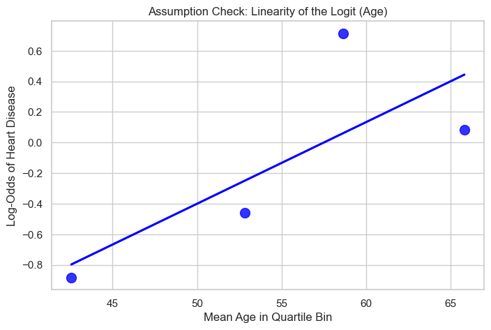

```python
df['Age_Bin'] = pd.qcut(df['Age'], q=4, labels=False)
bin_stats = df.groupby('Age_Bin').agg({'Age': 'mean', 'HD': 'mean'})
bin_stats['Logit'] = np.log(bin_stats['HD'] / (1 - bin_stats['HD'] + 1e-5))

plt.figure(figsize=(8, 5))
sns.regplot(x='Age', y='Logit', data=bin_stats, scatter_kws={'s': 100}, ci=None, color='blue')
plt.title('Assumption Check: Linearity of the Logit (Age)')
plt.xlabel('Mean Age in Quartile Bin')
plt.ylabel('Log-Odds of Heart Disease')
plt.savefig('linearity_of_logit.png')
print("[1.3A] Linearity of logit plot saved as 'linearity_of_logit.png'.")
```

**B) Homoscedasticity / Residual Check (Pearson residuals vs Fitted)**

```
[1.3B] Residual plot saved as 'residuals_vs_fitted.png'.
```

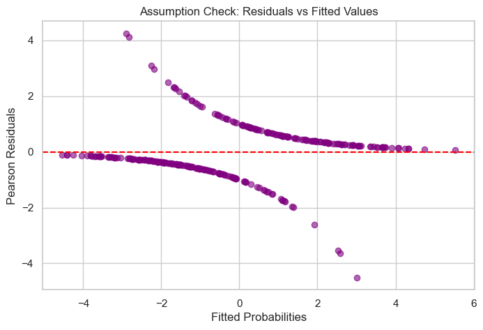

```python
fitted_vals = stat_model.fittedvalues
pearson_resid = stat_model.resid_pearson

plt.figure(figsize=(8, 5))
plt.scatter(fitted_vals, pearson_resid, alpha=0.6, color='purple')
plt.axhline(0, color='red', linestyle='--')
plt.xlabel('Fitted Probabilities')
plt.ylabel('Pearson Residuals')
plt.title('Assumption Check: Residuals vs Fitted Values')
plt.savefig('residuals_vs_fitted.png')
print("[1.3B] Residual plot saved as 'residuals_vs_fitted.png'.")
```

This graph displays Pearson residuals versus fitted values (represented as log-odds on the x-axis) for a logistic regression model. The plot reveals the characteristic "double-band" structure inherent to binary data: the upper curve represents patients with heart disease (HD=1), while the lower curve represents those without (HD=0).

While non-constant variance (heteroscedasticity) is expected in logistic regression, distinct outliers are visible at the far ends. For example, points with high positive residuals at low fitted values represent cases where the model confidently predicted "No Disease" incorrectly. These influential observations warrant further investigation.

### **PART 2: Transitioning to Machine Learning (scikit-learn)**

#### **NOTE: statsmodels (Inference) vs scikit-learn (Prediction)**

statsmodels provides rich statistical diagnostics (p-values, CI, ORs) but lacks built-in ML workflows (scaling, cross-validation, regularization). scikit-learn is optimized for predictive performance and generalization.

#### **2.1 Prepare Data for scikit-learn**

##### **NOTE: Encoding for ML**

scikit-learn requires ALL categories to be represented (no drop_first), and it handles the intercept internally, so we keep all dummy columns.

##### **NOTE: statsmodels (Inference) vs scikit-learn (Prediction)]**

statsmodels provides rich statistical diagnostics (p-values, CI, ORs) but lacks built-in ML workflows (scaling, cross-validation, regularization). scikit-learn is optimized for predictive performance and generalization.

```python
features_ml = ['Age', 'Sex', 'RestBP', 'Chol', 'MaxHR', 'ExAng', 'Oldpeak', 'Ca', 'ChestPain', 'Thal']
X = pd.get_dummies(df[features_ml], drop_first=False, dtype=int)
y = df['HD']
```

#### **2.2 Train/Test Split (Stratified to maintain class balance)**

```python
X_train, X_test, y_train, y_test = train_test_split(
    X, y, test_size=0.25, random_state=42, stratify=y
)
```

#### **2.3 Feature Scaling (Crucial for Regularization and Distance-based ML)**

```python
numeric_cols = ['Age', 'RestBP', 'Chol', 'MaxHR', 'Oldpeak', 'Ca']
scaler = StandardScaler()
X_train_scaled = X_train.copy()
X_test_scaled = X_test.copy()
X_train_scaled[numeric_cols] = scaler.fit_transform(X_train[numeric_cols])
X_test_scaled[numeric_cols] = scaler.transform(X_test[numeric_cols])
```

#### **2.4 Regularization: L2 (Ridge) vs L1 (Lasso)**

> L2 shrinks coefficients evenly; L1 can drive coefficients to exactly zero (feature selection)

### **L1 vs L2 Regularization: Coefficient Shrinkage and Feature Selection**

#### **1. Why regularization is needed**

Consider the ordinary least squares (OLS) regression model:

$$ y = X\beta + \varepsilon $$

where:

- $y$ = response vector
- $X$ = $n\times p$ predictor matrix
- $\beta=(\beta_1,\beta_2,\ldots,\beta_p)^T$ = regression coefficients
- $\varepsilon$ = error vector

OLS estimates the coefficients by minimizing the residual sum of squares:

$$ \hat{\beta}_{OLS} = \arg\min_{\beta} \left\{ \|y-X\beta\|_2^2 \right\} $$

The solution is:

$$ \boxed{ \hat{\beta}_{OLS}=(X^TX)^{-1}X^Ty } $$

provided (X^TX) is invertible.

### **Problem**

When predictors are highly correlated or when $p$ is large relative to $n$, OLS coefficients can become:

- unstable,
- excessively large,
- sensitive to small changes in the data,
- difficult to interpret.

Regularization addresses this by adding a **penalty for large coefficients**.

#### **2. General regularized regression framework**

A general penalized regression objective can be written as:

$$ \boxed{ \min_{\beta} \left[ \underbrace{\|y-X\beta\|_2^2}_{\text{Model fit}} + \lambda \underbrace{P(\beta)}_{\text{Penalty}} \right] } $$

where:

$$ \lambda\geq0 $$

is the **regularization parameter**.

- $\lambda=0$: ordinary least squares.
- Small $\lambda$: weak regularization.
- Large $\lambda$: strong regularization.

The difference between Ridge and Lasso is the choice of $P(\beta)$.

#### **3. L2 Regularization — Ridge Regression**

Ridge regression uses the squared (L_2)-norm:

$$ P(\beta)=\sum_{j=1}^{p}\beta_j^2 $$

Therefore:

$$ \boxed{ \hat{\beta}_{Ridge} = \arg\min_{\beta} \left[ \sum_{i=1}^{n} (y_i-\beta_0-\sum_{j=1}^{p}x_{ij}\beta_j)^2 + \lambda\sum_{j=1}^{p}\beta_j^2 \right] } $$

The intercept (\beta_0) is normally **not penalized**.

#### **4. Derivation of the Ridge estimator**

Ignoring the intercept for simplicity:

$$ L(\beta) = (y-X\beta)^T(y-X\beta) + \lambda\beta^T\beta $$

Expand the first term:

$$ L(\beta) = y^Ty-2\beta^TX^Ty+\beta^TX^TX\beta +\lambda\beta^T\beta $$

Differentiate with respect to (\beta):

$$ \frac{\partial L}{\partial\beta} = -2X^Ty+2X^TX\beta+2\lambda\beta $$

Set the derivative equal to zero:

$$ -2X^Ty+2X^TX\beta+2\lambda\beta=0 $$

Divide by 2:

$$ -X^Ty+X^TX\beta+\lambda\beta=0 $$

Therefore:

$$ (X^TX+\lambda I)\beta=X^Ty $$

and hence:

$$ \boxed{ \hat{\beta}_{Ridge} = (X^TX+\lambda I)^{-1}X^Ty } $$

This is the fundamental Ridge estimator.

#### **5. Why Ridge shrinks coefficients**

Suppose, for simplicity, that the predictors are standardized and mutually orthogonal:

$$ X^TX=I $$

Then:

$$ \hat{\beta}_{Ridge} = (I+\lambda I)^{-1}X^Ty $$

$$ = \frac{1}{1+\lambda}X^Ty $$

Since:

$$ \hat{\beta}_{OLS}=X^Ty $$

we obtain:

$$ \boxed{ \hat{\beta}_{Ridge,j} = \frac{1}{1+\lambda} \hat{\beta}_{OLS,j} } $$

Thus every coefficient is multiplied by the same shrinkage factor under this simplified orthogonal-predictor case.

For example, if:

$$ \lambda=3 $$

then:

$$ \frac{1}{1+\lambda} = \frac14 $$

so:

$$ \hat{\beta}_{Ridge,j} = 0.25\hat{\beta}_{OLS,j} $$

A coefficient of (8) becomes:

$$ 8(0.25)=2 $$

A coefficient of (-4) becomes:

$$ -4(0.25)=-1 $$

#### **Important qualification**

It is more precise to say:

> **L2 regularization continuously shrinks coefficients toward zero but generally does not set them exactly equal to zero.**

The "shrinks coefficients evenly" statement is exactly true in the simple orthogonal standardized case; with correlated predictors, the amount of shrinkage can differ across coefficients.

#### **6. L1 Regularization — Lasso Regression**

Lasso uses the absolute value of the coefficients:

$$ P(\beta)=\sum_{j=1}^{p}|\beta_j| $$

Therefore:

$$ \boxed{ \hat{\beta}_{Lasso} = \arg\min_{\beta} \left[ \sum_{i=1}^{n} (y_i-\beta_0-\sum_{j=1}^{p}x_{ij}\beta_j)^2 + \lambda\sum_{j=1}^{p}|\beta_j| \right] } $$

The crucial difference is:

$$ \boxed{\text{Ridge: }\sum\beta_j^2} $$

versus

$$ \boxed{\text{Lasso: }\sum|\beta_j|} $$

#### **7. Why L1 can produce exactly zero coefficients**

This is the most important mathematical distinction.

Consider a single standardized predictor with:

$$ \sum_i x_i^2=1 $$

and define:

$$ z=X^Ty $$

The Lasso objective for one coefficient can be written as:

$$ L(\beta) = \frac12(z-\beta)^2+\lambda|\beta| $$

For (\beta>0):

$$ |\beta|=\beta $$

so:

$$ L(\beta) = \frac12(z-\beta)^2+\lambda\beta $$

Differentiate:

$$ \frac{dL}{d\beta} = \beta-z+\lambda $$

Set equal to zero:

$$ \beta-z+\lambda=0 $$

Therefore:

$$ \beta=z-\lambda $$

This solution is valid only when:

$$ z>\lambda $$

For (\beta<0):

$$ |\beta|=-\beta $$

so:

$$ L(\beta) = \frac12(z-\beta)^2-\lambda\beta $$

Differentiate:

$$ \frac{dL}{d\beta} = \beta-z-\lambda $$

Setting equal to zero:

$$ \beta=z+\lambda $$

This is valid when:

$$ z<-\lambda $$

#### **8. The soft-thresholding solution**

Combining the three cases gives:

$$ \boxed{ \hat{\beta}_{Lasso} = S(z,\lambda) } $$

where (S) is the **soft-thresholding operator**:

$$ \boxed{ S(z,\lambda) = \begin{cases} z-\lambda, & z>\lambda\\[4pt] 0, & |z|\leq\lambda\\[4pt] z+\lambda, & z<-\lambda \end{cases} } $$

Alternatively:

$$ \boxed{ S(z,\lambda) = \operatorname{sign}(z)(|z|-\lambda)_+ } $$

where:

$$ (a)_+=\max(a,0) $$

This equation mathematically explains **why Lasso performs feature selection**.

#### **9. Numerical example**

Suppose the unregularized coefficient signal is:

$$ z=0.4 $$

and:

$$ \lambda=0.5 $$

Then:

$$ |z|=0.4<0.5 $$

Therefore:

$$ \boxed{\hat{\beta}_{Lasso}=0} $$

The predictor is effectively removed from the model.

But suppose:

$$ z=2 $$

Then:

$$ \hat{\beta}_{Lasso} = 2-0.5 = 1.5 $$

Thus:

$$ 2\rightarrow1.5 $$

A large coefficient is shrunk but survives.

#### **10. Why Ridge does not normally produce zero coefficients**

For the same simplified one-variable problem, Ridge minimizes:

$$ L(\beta) = \frac12(z-\beta)^2 + \frac{\lambda}{2}\beta^2 $$

Differentiate:

$$ \frac{dL}{d\beta} = \beta-z+\lambda\beta $$

Set equal to zero:

$$ (1+\lambda)\beta=z $$

Therefore:

$$ \boxed{ \hat{\beta}_{Ridge} = \frac{z}{1+\lambda} } $$

For any finite (\lambda):

$$ z\neq0 \quad\Rightarrow\quad \hat{\beta}_{Ridge}\neq0 $$

Hence Ridge generally **shrinks toward zero but does not reach zero**.

#### **11. Geometric explanation**

Another powerful way to understand the difference is through constrained optimization.

Instead of writing regularization as a penalty, we can write it as a constraint.

### Ridge

Ridge approximately solves:

$$ \min_{\beta}\|y-X\beta\|^2 $$

subject to:

$$ \boxed{ \sum_{j=1}^{p}\beta_j^2\leq t } $$

This creates a **circular/spherical constraint region**.

### Lasso

Lasso solves:

$$ \min_{\beta}\|y-X\beta\|^2 $$

subject to:

$$ \boxed{ \sum_{j=1}^{p}|\beta_j|\leq t } $$

For two predictors, this is a **diamond-shaped region**.

[figure not shown]

The key feature is that the L1 constraint has **sharp corners located on the coordinate axes**.

The optimum frequently occurs at one of these corners.

At a corner:

$$ \beta_j=0 $$

Therefore Lasso naturally produces zero coefficients.

The L2 constraint is smooth, so the optimum is much less likely to land exactly on an axis.

#### **12. Derivative explanation: another key insight**

The mathematical reason can also be seen from the derivatives.

### **L2 penalty**

$$ P(\beta)=\beta^2 $$

Derivative:

$$ P'(\beta)=2\beta $$

At zero:

$$ P'(0)=0 $$

So the penalty's gradient becomes progressively smaller as (\beta) approaches zero.

### L1 penalty

$$ P(\beta)=|\beta| $$

For (\beta>0):

$$ P'(\beta)=1 $$

For (\beta<0):

$$ P'(\beta)=-1 $$

At zero, the ordinary derivative does not exist. Instead, the **subgradient** is:

$$ \boxed{ \partial|\beta|\big|_{\beta=0}=[-1,1] } $$

This creates a range of values that can balance the gradient of the loss function and make:

$$ \boxed{\beta=0} $$

an optimal solution.

This is the deeper mathematical reason behind Lasso's sparsity.

#### **13. Summary Comparison**

[output not shown]

#### **14. A useful intuition**

Think of the two penalties this way:

#### **Ridge — "Keep everyone, but control their influence"**

$$ \boxed{ \beta_j\rightarrow\text{small but usually non-zero} } $$

Ridge tends to distribute the predictive contribution among correlated variables.

#### **Lasso — "Keep the strongest, eliminate the weakest"**

$$ \boxed{ \beta_j\rightarrow0 } $$

for sufficiently weak predictors.

Thus:

> **L2 regularization controls coefficient magnitude, whereas L1 regularization controls coefficient magnitude and can simultaneously perform variable selection.**

#### **15. What happens as $\lambda$ changes?**

For both methods:

$$ \lambda=0 $$

gives:

$$ \hat{\beta}=\hat{\beta}_{OLS} $$

As (\lambda) increases:

#### **Ridge**

$$ |\hat{\beta}_{Ridge,j}| \downarrow $$

but generally:

$$ \hat{\beta}_{Ridge,j}\neq0 $$

#### **Lasso**

$$ |\hat{\beta}_{Lasso,j}| \downarrow $$

and sufficiently weak coefficients satisfy:

$$ \boxed{ \hat{\beta}_{Lasso,j}=0 } $$

For sufficiently large (\lambda), Lasso can drive **all slope coefficients to zero**.

#### **16. The most important equations to remember**

##### **Ridge**

$$ \boxed{ \hat{\beta}_{Ridge} = (X^TX+\lambda I)^{-1}X^Ty } $$

and, in the orthogonal case:

$$ \boxed{ \hat{\beta}_{Ridge,j} = \frac{1}{1+\lambda}\hat{\beta}_{OLS,j} } $$

##### **Lasso**

$$ \boxed{ \hat{\beta}_{Lasso} = \arg\min_\beta \left\{ \|y-X\beta\|^2+ \lambda\sum_j|\beta_j| \right\} } $$

and its fundamental one-dimensional solution is:

$$ \boxed{ \hat{\beta}_{Lasso} = \operatorname{sign}(z)(|z|-\lambda)_+ } $$

That **soft-thresholding equation** is probably the single best equation to remember when explaining why **L1 can perform feature selection whereas L2 generally cannot**.

- **Ridge Regression:** A regression method that **shrinks the coefficients of variables toward zero** to reduce overfitting, but usually **keeps all variables** in the model.
- **Lasso Regression:** A regression method that **shrinks coefficients toward zero and can make some coefficients exactly zero**, effectively **removing less important variables** from the model.

### **Easy way to remember**

> **Ridge = Shrinks variables**

> **Lasso = Shrinks + removes variables**

```python
lr_l2 = LogisticRegression(penalty='l2', C=1.0, solver='lbfgs', max_iter=1000, random_state=42)
lr_l1 = LogisticRegression(penalty='l1', C=1.0, solver='saga', max_iter=1000, random_state=42)

lr_l2.fit(X_train_scaled, y_train)
lr_l1.fit(X_train_scaled, y_train)

print("\n[2.4] Regularization Comparison (First 5 Feature Coefficients):")
coef_compare = pd.DataFrame({
    'Feature': X.columns[:5],
    'Unregularized (statsmodels)*': stat_model.params[:5].values, # Approximate alignment
    'L2 (Ridge) Coef': lr_l2.coef_[0][:5],
    'L1 (Lasso) Coef': lr_l1.coef_[0][:5]
})
print(coef_compare.round(4))
print("(*Note: statsmodels coeffs are on un-scaled data and may use different reference categories)")
```

```
[2.4] Regularization Comparison (First 5 Feature Coefficients):
  Feature  Unregularized (statsmodels)*  L2 (Ridge) Coef  L1 (Lasso) Coef
0     Age                       -6.8953           0.0635           0.0362
1     Sex                        1.8756           1.0898           1.0639
2  RestBP                        2.2927           0.1684           0.1392
3    Chol                        0.2217           0.2427           0.2256
4   MaxHR                        0.7095          -0.4551          -0.4297
(*Note: statsmodels coeffs are on un-scaled data and may use different reference categories)
```

#### **PART 3: Comparing Classifiers**

#### **3.1 Define Models**

```python
models = {
    "Logistic Regression (L2)": LogisticRegression(penalty='l2', C=1.0, solver='lbfgs', max_iter=1000, random_state=42),
    "Decision Tree (Non-linear)": DecisionTreeClassifier(max_depth=4, min_samples_split=10, random_state=42)
}
```

##### **3.2 Cross-Validation Strategy (Stratified K-Fold)**

> Ensures the model generalizes to unseen patients and maintains class ratio in each fold

```python
cv = StratifiedKFold(n_splits=5, shuffle=True, random_state=42)

print("\n[3.2] 5-Fold Stratified Cross-Validation Results:")
for name, model in models.items():
    # Scale data for LR, but NOT for Decision Tree (trees are scale-invariant)
    X_cv = X_train_scaled if "Logistic" in name else X_train

    roc_scores = cross_val_score(model, X_cv, y_train, cv=cv, scoring='roc_auc')
    f1_scores = cross_val_score(model, X_cv, y_train, cv=cv, scoring='f1')

    print(f"{name}:")
    print(f"  Mean ROC-AUC: {roc_scores.mean():.3f} (+/- {roc_scores.std():.3f})")
    print(f"  Mean F1-Score: {f1_scores.mean():.3f} (+/- {f1_scores.std():.3f})")
```

```
[3.2] 5-Fold Stratified Cross-Validation Results:
Logistic Regression (L2):
  Mean ROC-AUC: 0.895 (+/- 0.054)
  Mean F1-Score: 0.799 (+/- 0.051)
Decision Tree (Non-linear):
  Mean ROC-AUC: 0.841 (+/- 0.075)
  Mean F1-Score: 0.766 (+/- 0.079)
```

#### **3.3 Test Set Evaluation**

```python
print("\n[3.3] Test Set Evaluation:")

for name, model in models.items():
    # Logistic Regression uses scaled data; Decision Tree uses unscaled data.
    X_train_eval = X_train_scaled if "Logistic" in name else X_train
    X_test_eval = X_test_scaled if "Logistic" in name else X_test

    # Cross-validation fits cloned models, so fit the original model here.
    model.fit(X_train_eval, y_train)

    y_pred = model.predict(X_test_eval)
    y_pred_prob = model.predict_proba(X_test_eval)[:, 1]

    print(f"\n--- {name} ---")
    print(f"ROC-AUC: {roc_auc_score(y_test, y_pred_prob):.3f}")
    print(f"F1-Score: {f1_score(y_test, y_pred):.3f}")
    print("Confusion Matrix:")
    print(confusion_matrix(y_test, y_pred))
```

```
[3.3] Test Set Evaluation:

--- Logistic Regression (L2) ---
ROC-AUC: 0.934
F1-Score: 0.849
Confusion Matrix:
[[34  7]
 [ 4 31]]

--- Decision Tree (Non-linear) ---
ROC-AUC: 0.811
F1-Score: 0.704
Confusion Matrix:
[[30 11]
 [10 25]]
```

#### **PART 4: Interpretability vs. Predictive Power**

#### **4.1 Explainability Comparison**

> Logistic Regression: Global, directional, magnitude-based (Odds Ratios)

> Decision Tree: Local, non-linear, hierarchy-based (Feature Importances)

```python
lr_feature_importance = pd.DataFrame({
    'Feature': X.columns,
    'LR_Abs_Coefficient': np.abs(lr_l2.coef_[0]),
    'LR_Direction': np.sign(lr_l2.coef_[0])
}).sort_values(by='LR_Abs_Coefficient', ascending=False).head(5)

dt_feature_importance = pd.DataFrame({
    'Feature': X.columns,
    'DT_Importance': models["Decision Tree (Non-linear)"].feature_importances_
}).sort_values(by='DT_Importance', ascending=False).head(5)

print("\n[4.1] Top 5 Features by Importance:")
print("Logistic Regression (by absolute coefficient magnitude):")
lr_feature_importance.round(3)
```

```
[4.1] Top 5 Features by Importance:
Logistic Regression (by absolute coefficient magnitude):
```

|  | Feature | LR_Abs_Coefficient | LR_Direction |
| --- | --- | --- | --- |
| 1 | Sex | 1.090 | 1.0 |
| 8 | ChestPain_asymptomatic | 1.046 | 1.0 |
| 7 | Ca | 1.041 | 1.0 |
| 13 | Thal_normal | 0.858 | -1.0 |
| 14 | Thal_reversable | 0.677 | 1.0 |

```python
print("\nDecision Tree (by Gini importance):")
dt_feature_importance.round(3)
```

```
Decision Tree (by Gini importance):
```

|  | Feature | DT_Importance |
| --- | --- | --- |
| 13 | Thal_normal | 0.414 |
| 8 | ChestPain_asymptomatic | 0.200 |
| 7 | Ca | 0.132 |
| 4 | MaxHR | 0.094 |
| 3 | Chol | 0.069 |

#### **4.2 Stratified Analysis: Does performance vary across demographics?**

We evaluate the best performing model (let's assume Logistic Regression for stability) on different subgroups of the TEST set.

```python
best_model = lr_l2
X_test_best = X_test_scaled

# Create a temporary dataframe to merge predictions with demographics
test_eval_df = X_test.copy()
test_eval_df['True_HD'] = y_test.values
test_eval_df['Pred_Prob'] = best_model.predict_proba(X_test_best)[:, 1]
test_eval_df['Age_Group'] = df.loc[X_test.index, 'Age_Group'].values
test_eval_df['Sex_Label'] = df.loc[X_test.index, 'Sex_Label'].values

print("\n[4.2] Stratified Model Performance (ROC-AUC by Subgroup):")
subgroups = {
    "Overall": test_eval_df,
    "Male": test_eval_df[test_eval_df['Sex_Label'] == 'Male'],
    "Female": test_eval_df[test_eval_df['Sex_Label'] == 'Female'],
    "Age <= 60": test_eval_df[test_eval_df['Age_Group'] == '<=60'],
    "Age > 60": test_eval_df[test_eval_df['Age_Group'] == '>60']
}

for group_name, group_df in subgroups.items():
    if len(group_df['True_HD'].unique()) > 1: # Need both classes for ROC-AUC
        group_auc = roc_auc_score(group_df['True_HD'], group_df['Pred_Prob'])
        print(f"  {group_name:12} | N={len(group_df):3} | ROC-AUC: {group_auc:.3f}")
    else:
        print(f"  {group_name:12} | N={len(group_df):3} | ROC-AUC: N/A (Single class in subset)")
```

```
[4.2] Stratified Model Performance (ROC-AUC by Subgroup):
  Overall      | N= 76 | ROC-AUC: 0.934
  Male         | N= 50 | ROC-AUC: 0.902
  Female       | N= 26 | ROC-AUC: 0.980
  Age <= 60    | N= 58 | ROC-AUC: 0.950
  Age > 60     | N= 18 | ROC-AUC: 0.901
```